# BANKS_Final_Project

### Welcome

Welcome to my final project for Biol3100. This is where I will be showing what I have learned this semester. For this final project I will be taking a data set and walking you through the cleaning, plotting and analysis.

This summer I have been working a lot with Algae in Utah Lake and I have gained a curiosity on the subject. I originally was going to do my final project on the algal blooms in Utah Lake however, the data that I received for that project was not sufficient for what I wanted to do. Instead of perusing with Utah Lake I decided to look up data about algal blooms in a different location and it appeared that California had just what I was looking for

### Cleaning the data

```
## [1] "river"     "lake"      "bay"       "reservoir" "pond"
```

### Plot 1

Here is a very simple plot that will show the location of the Algal blooms along the state of Califonia.

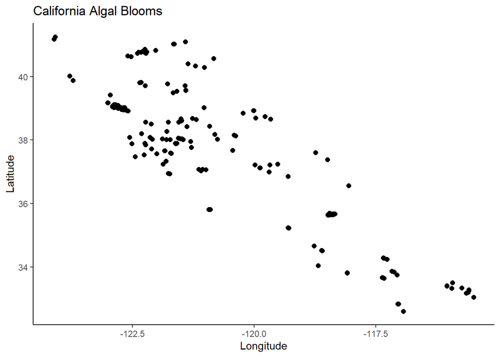

### Plot 2

[interactive chart not shown]

I wanted to try something just a little more advanced by using the Leaflet Package. This plot shows the location of the algal blooms along California but I have added colored markers that label the water body type of each algal bloom.

### Plot 3

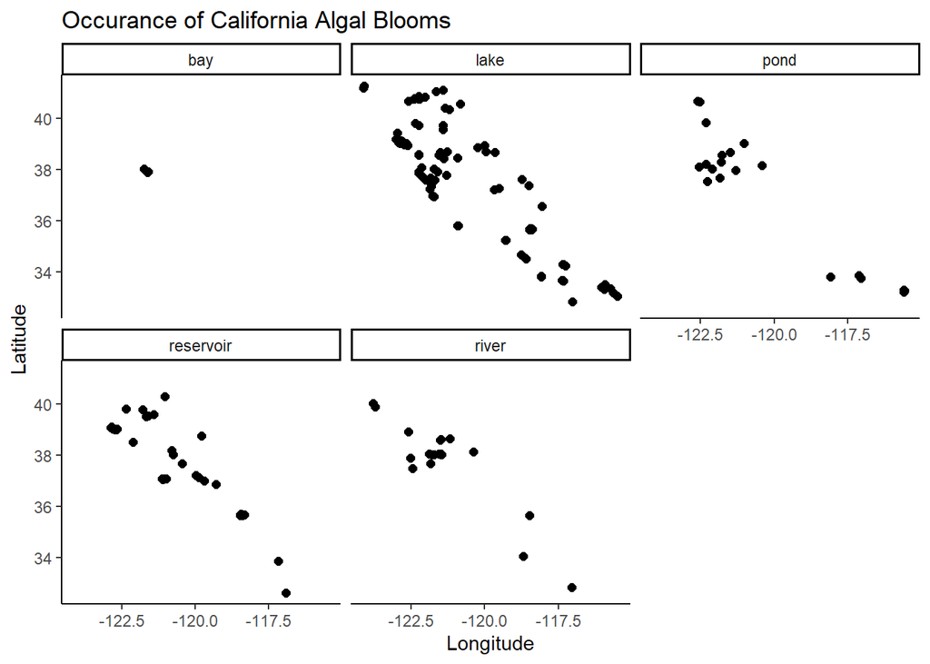

This final plot uses a facet wrap to visualize the occurrence of algal blooms in different water body types. We can see from this graph that the most algal blooms occure in lakes.